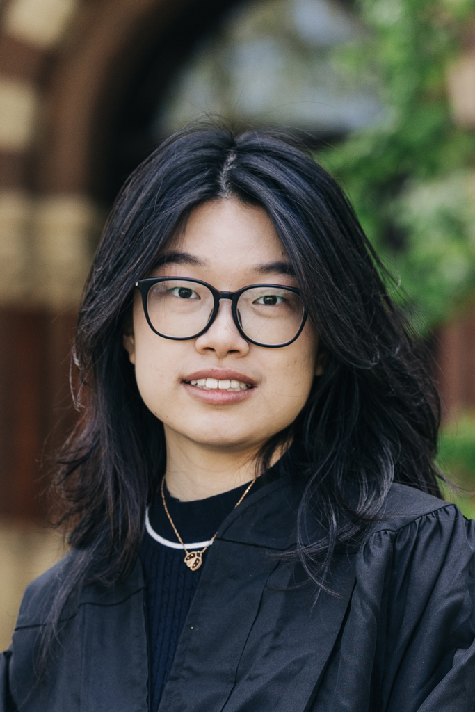

# About Me

## 👋 Hi

I’m Shiyi Zhang, a first year ScM student of the Biostatisitics Department. I graduated from [Smith College](https://www.smith.edu/) with a B.A in Neuroscience. My past research experiences were mainly in the area of molecular neuroscience i.e. signaling pathways of neurogenesis, molecular profile of adult neurogenesis.

## 📊 Statistics Background

I found statistics very interesting in my third year at Smith through taking the multiple regression class with Dr. Cook. I had little experience in programming and I wish to strengthen my relationship with programming languages through this class.

## 🎉 Fun Facts

1. I love binge-watching cooking shows.
2. My favorite color is green.
3. I collected receipts, tags, and coffee packaging.
4. I eat everything with cheese. (You should try goat cheese with Chinese buns!)
5. When stressed, I start to make travel plans.

## 👩‍🍳 For cooking lovers like me

Here are some very interesting cookbooks that I enjoy reading:

1. SIMPLE by Ottolenghi (The recipe is easy to follow and for each dish, there is a dish picture that helps you to visualize the final product).
2. Six Seasons of Pasta by Joshua McFadden (The book is organized by seasons, which is very helpful for cooking with fresh ingredients).
3. Dac Biet by Nini Nguyen (Shaking beef with watercress salad is a must-try dish in this book).